# Improvising Risk Prediction of Early Stage Diabetes

Improvising Risk Prediction of Early Stage Diabetes

The dataset used in this study is publicly available in the UCI Machine Learning Repository website. The data has been collected using direct questionnaires from the patients of Sylhet Diabetes Hospital in Sylhet, Bangladesh.

**Various Steps involved:**

1. **Preprocessing:** Dealing with missing values and Outliers, Encoding Data, Scaling Data, Data Splitting
2. **Exploratory data analysis**
3. **Feature Selection:** Pearson Correlation Coefficient, Univariate Selection: SelectKBest method using chi-squared statistical test and Random Forest Classifier: Feature Importance.
4. **Model building:** Logistic regression, K-nearest neighbors classifier, Decision tree classifier, Support vector classifier, Random forest classifier and Naive Bayes algorithms
5. **Hyperparameter Tuning:** Decision tree classifier, Support vector classifier, and Random forest classifier

**Importing the required libraries**

```python
import numpy as np
import pandas as pd
import matplotlib.pyplot as plt
import seaborn as sns
from sklearn.preprocessing import LabelEncoder
from sklearn.preprocessing import StandardScaler
from sklearn.model_selection import train_test_split
from sklearn.model_selection import cross_val_score
from sklearn.metrics import accuracy_score, f1_score, precision_score,confusion_matrix, recall_score, roc_auc_score
from sklearn.linear_model import LogisticRegression
from sklearn.neighbors import KNeighborsClassifier
from sklearn.tree import DecisionTreeClassifier
from sklearn.svm import SVC
from sklearn.ensemble import RandomForestClassifier
from sklearn.naive_bayes import GaussianNB
from sklearn.feature_selection import SelectKBest
from sklearn.feature_selection import chi2
from sklearn.model_selection import GridSearchCV
from sklearn.metrics import plot_roc_curve
```

1. **numpy:** To perform scientific computing and data manipulation on multi-dimensional arrays and matrices
2. **pandas:** Used for data manipulation and analysis
3. **matplotlib and seaborn:** For Data Visualisation
4. **sklearn:** Scikit-learn is used for implementing machine learning algorithms, feature extractions and performance metrics of predicted models

**Loading Dataset**

```python
diabetes_data = pd.read_csv("https://archive.ics.uci.edu/ml/machine-learning-databases/00529/diabetes_data_upload.csv")
diabetes_data.head()
```

|  | Age | Gender | Polyuria | Polydipsia | sudden weight loss | weakness | Polyphagia | Genital thrush | visual blurring | Itching | Irritability | delayed healing | partial paresis | muscle stiffness | Alopecia | Obesity | class |
| --- | --- | --- | --- | --- | --- | --- | --- | --- | --- | --- | --- | --- | --- | --- | --- | --- | --- |
| 0 | 40 | Male | No | Yes | No | Yes | No | No | No | Yes | No | Yes | No | Yes | Yes | Yes | Positive |
| 1 | 58 | Male | No | No | No | Yes | No | No | Yes | No | No | No | Yes | No | Yes | No | Positive |
| 2 | 41 | Male | Yes | No | No | Yes | Yes | No | No | Yes | No | Yes | No | Yes | Yes | No | Positive |
| 3 | 45 | Male | No | No | Yes | Yes | Yes | Yes | No | Yes | No | Yes | No | No | No | No | Positive |
| 4 | 60 | Male | Yes | Yes | Yes | Yes | Yes | No | Yes | Yes | Yes | Yes | Yes | Yes | Yes | Yes | Positive |

The dataset having 520 observations contains 16 features and one target variable named class having values Positive and Negative which indicates the likelihood whether the patient would be at risk for diabetes or not. Out of the 16 features, one feature Age is quantitative and other 15 features are Categorical with Yes/No values and Gender with Male/Female values.

```python
# Summary of the dataset
diabetes_data.info()
```

[output not shown]

```python
# Checking if any null values or NAN or NA values are present that needs to be removed
diabetes_data.isnull().sum()
```

```
Age                   0
Gender                0
Polyuria              0
Polydipsia            0
sudden weight loss    0
weakness              0
Polyphagia            0
Genital thrush        0
visual blurring       0
Itching               0
Irritability          0
delayed healing       0
partial paresis       0
muscle stiffness      0
Alopecia              0
Obesity               0
class                 0
dtype: int64
```

There are no null values or NAN or NA values present that needs to be removed.

```python
# Changing the headers to a proper format to maintain consistency during visualization (Capitalize each word using str.title() function)

headers = pd.Series(diabetes_data.columns)
diabetes_data.columns = headers.str.title()

# Renaming the target label column to 'Diabetes' from 'Class'

diabetes_data = diabetes_data.rename(columns = {'Class' : 'Diabetes'})
```

```python
# Looking at the unique values in each variable
for headers in diabetes_data.columns:
    print('Variable: ', headers, '\n', 'Unique Values: ', diabetes_data[headers].unique(), '\n')
```

```
Variable:  Age
 Unique Values:  [40 58 41 45 60 55 57 66 67 70 44 38 35 61 54 43 62 39 48 32 42 52 53 37
 49 63 30 50 46 36 51 59 65 25 47 28 68 56 31 85 90 72 69 79 34 16 33 64
 27 29 26]

Variable:  Gender
 Unique Values:  ['Male' 'Female']

Variable:  Polyuria
 Unique Values:  ['No' 'Yes']

Variable:  Polydipsia
 Unique Values:  ['Yes' 'No']

Variable:  Sudden Weight Loss
 Unique Values:  ['No' 'Yes']

Variable:  Weakness
 Unique Values:  ['Yes' 'No']

Variable:  Polyphagia
 Unique Values:  ['No' 'Yes']

Variable:  Genital Thrush
 Unique Values:  ['No' 'Yes']

Variable:  Visual Blurring
 Unique Values:  ['No' 'Yes']

Variable:  Itching
 Unique Values:  ['Yes' 'No']

Variable:  Irritability
 Unique Values:  ['No' 'Yes']

Variable:  Delayed Healing
 Unique Values:  ['Yes' 'No']

Variable:  Partial Paresis
 Unique Values:  ['No' 'Yes']

Variable:  Muscle Stiffness
 Unique Values:  ['Yes' 'No']

Variable:  Alopecia
 Unique Values:  ['Yes' 'No']

Variable:  Obesity
 Unique Values:  ['Yes' 'No']

Variable:  Diabetes
 Unique Values:  ['Positive' 'Negative']
```

```python
diabetes_data['Diabetes'].value_counts()
```

```
Positive    320
Negative    200
Name: Diabetes, dtype: int64
```

There are 320 observations where the label which indicates the likelihood of the risk of Diabetes is Positive and 200 observations the risk of Diabetes is Negative.

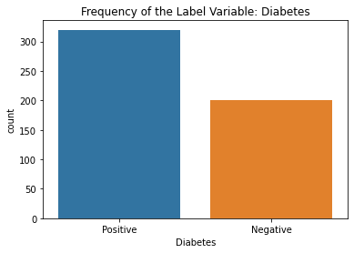

```python
count_diabetes = sns.countplot(diabetes_data['Diabetes'])
count_diabetes.set_title('Frequency of the Label Variable: Diabetes')
```

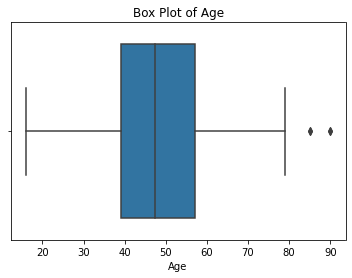

```python
# Checking for Outliers for Age Feature
sns.boxplot(diabetes_data["Age"]).set_title("Box Plot of Age")
```

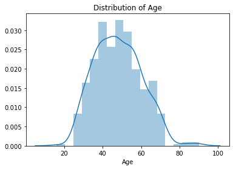

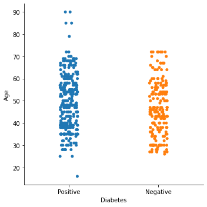

```python
# Distribution and Categorical Plot of Age feature
sns.distplot(diabetes_data['Age'])
plt.title("Distribution of Age")
sns.catplot(x='Diabetes',y='Age', data=diabetes_data)
plt.show()
```

```python
# Outliers
diabetes_data[diabetes_data['Age'] > 80]
```

[output not shown]

4 of the patients were within the range of 80-90 years and were found to be the outliers. From the data, it was found that patients above the age of 75 were more likely to be diagnosed with diabetes.

**Exploratory Data Analysis**

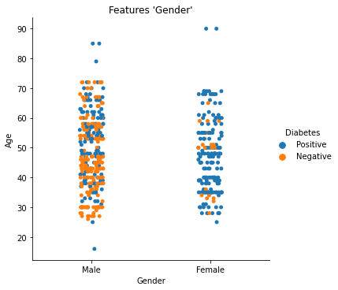

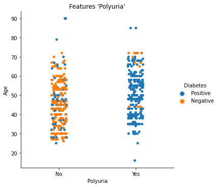

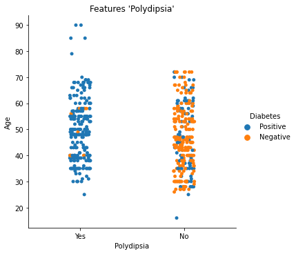

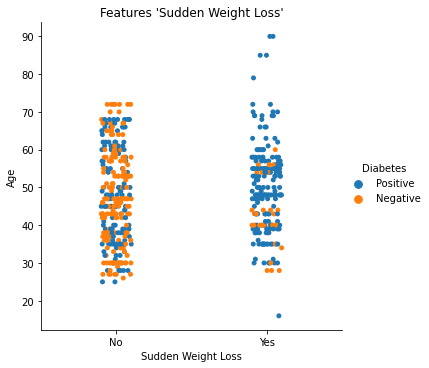

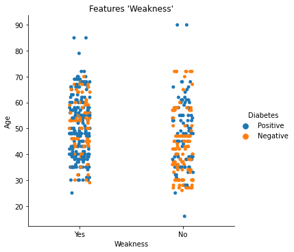

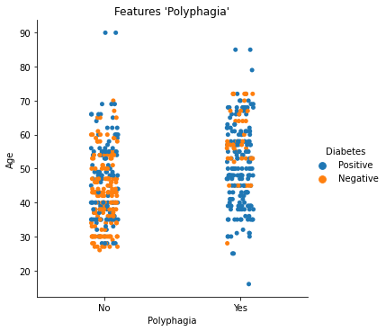

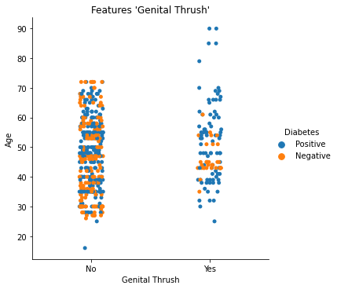

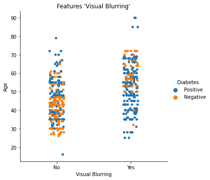

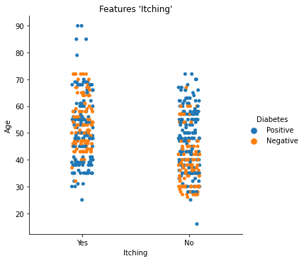

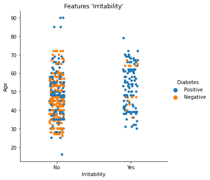

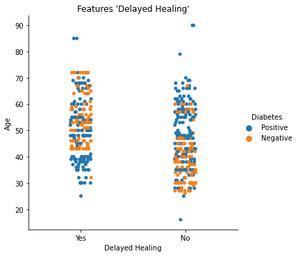

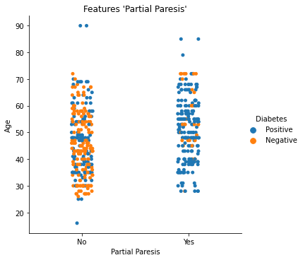

[3 more figures not shown]

```python
# Categorical Plot of all the features with respect to target variable Diabetes

for headers in diabetes_data.columns[:-1]:
    if headers not in ['Age']:
        sns.catplot(x=headers,y='Age',hue='Diabetes',data=diabetes_data)
        plt.title("Features '%s'"%headers)
        plt.show()
```

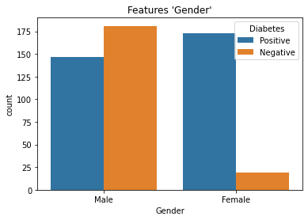

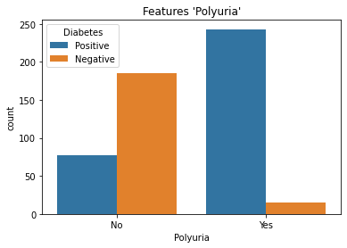

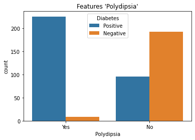

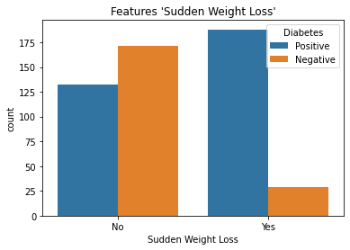

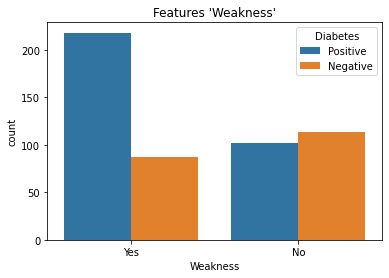

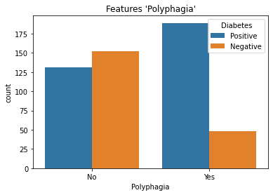

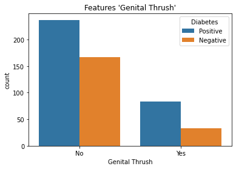

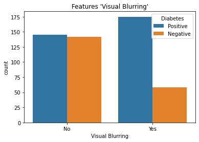

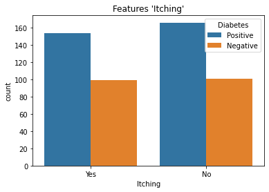

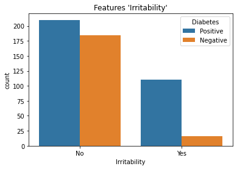

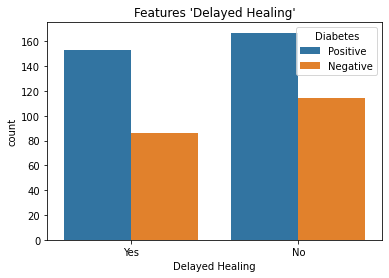

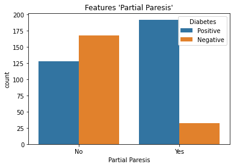

[3 more figures not shown]

```python
# Counts of all the features with respect to target variable Diabetes

for headers in diabetes_data.columns[:-1]:
    if headers not in ['Age']:
        sns.countplot(diabetes_data[headers],hue=diabetes_data['Diabetes'])
        plt.title("Features '%s'"%headers)
        plt.show()
```

**Label Encoding**

```python
le = LabelEncoder()

for headers in diabetes_data.columns[1:] :
    diabetes_data[headers] = le.fit_transform(diabetes_data[headers])
```

Label Encoding was used to convert the categorical features. Label Encoding replaces the value with a number between 0 and the number of distinct classes of the feature minus 1.

**Spliting the Dataset into Train and Test data**

```python
# Splits the data into train and test dataset in a ratio of 80:20

features = diabetes_data.drop('Diabetes', axis="columns")
classes = diabetes_data["Diabetes"]

train_features, test_features, train_class, test_class = train_test_split(features, classes, train_size=0.8, test_size=0.2, shuffle=True)

print("Training set: %d observations" % len(train_features))
print("Test set: %d observations" % len(test_features))
```

```
Training set: 416 observations
Test set: 104 observations
```

**Feature Selection**  
**Method 1: Pearson Correlation Coefficient**

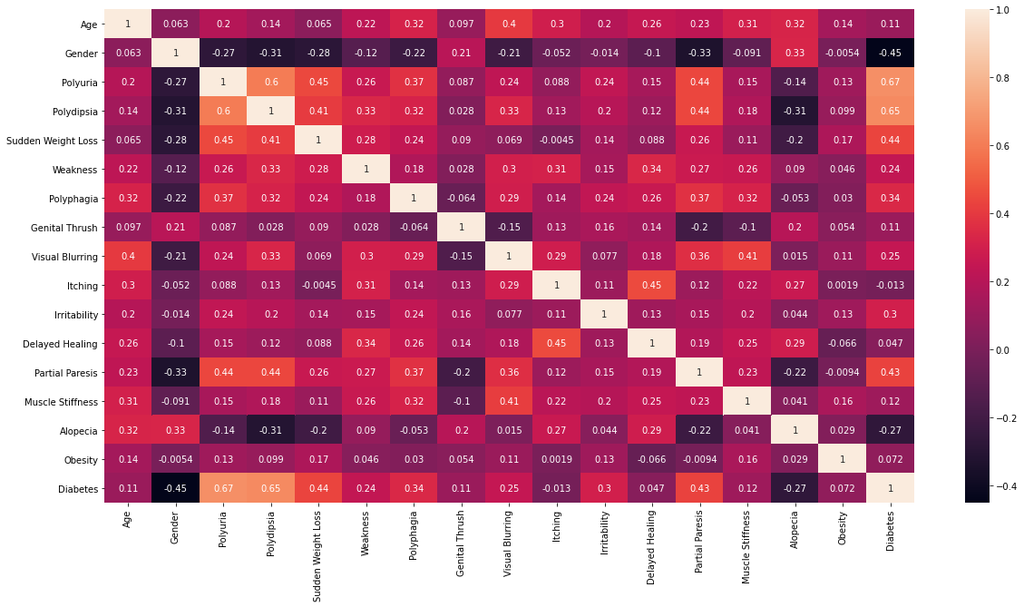

```python
# Plot Correlation with Heatmap

plt.figure(figsize=(20,10))
sns.heatmap(diabetes_data.corr(),annot=True)
plt.show()
```

```python
# Pearson Correlation Coefficient of the features with respect to the target Diabetes

features.corrwith(classes)
```

```
Age                   0.108679
Gender               -0.449233
Polyuria              0.665922
Polydipsia            0.648734
Sudden Weight Loss    0.436568
Weakness              0.243275
Polyphagia            0.342504
Genital Thrush        0.110288
Visual Blurring       0.251300
Itching              -0.013384
Irritability          0.299467
Delayed Healing       0.046980
Partial Paresis       0.432288
Muscle Stiffness      0.122474
Alopecia             -0.267512
Obesity               0.072173
dtype: float64
```

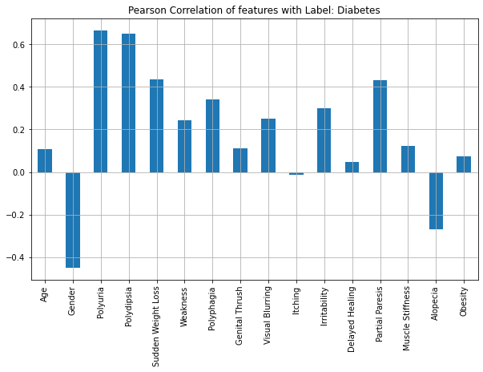

```python
# Plotting the scores from Pearson Correlation Coefficient method

plt.figure(figsize=(10,6))
features.corrwith(classes).plot.bar(
      title = "Pearson Correlation of features with Label: Diabetes",grid= True)
```

From the Pearson Correlation Coefficient scores, Polyuria (0.665922) and Polydipsia (0.648734) were found out to be strongly positively correlated with the target variable Diabetes and Gender (-0.449233) has the strongest negative correlation. The top 10 features selected using this technique are Polyuria, Polydipsia, Gender, Sudden Weight Loss, Partial Paresis, Polyphagia, Irritability, Alopecia, Visual Blurring and Weakness.

**Scaling Data**

```python
scaler = StandardScaler()
train_data = scaler.fit_transform(train_features)
test_data = scaler.transform(test_features)
```

Standardization scales each feature’s distribution to have a mean of 0 and standard deviation of 1.

**Baseline models: Default Parameters and all the features**

```python
def run_models(training_data, test_data, class_train, class_test):
    classifiers = [LogisticRegression(),KNeighborsClassifier(),DecisionTreeClassifier(),RandomForestClassifier(),SVC(),GaussianNB()]

    models = {"Logistic Regression": LogisticRegression(), "K-Nearest Neighbors": KNeighborsClassifier(),
              "Decision Tree": DecisionTreeClassifier(),"Support Vector Machine": SVC(),
              "Random Forest": RandomForestClassifier(), "Naive Bayes":GaussianNB()}

    baseline_results = pd.DataFrame()
    for key,value in models.items():
        model = value.fit(training_data, class_train)

        # 10 Fold Cross Validation on Training Data
        cv_accuracy_score = cross_val_score(estimator=value, X=training_data ,y=class_train,cv=10)

        prediction = model.predict(test_data)

        accuracy = accuracy_score(prediction,class_test)
        roc_score = roc_auc_score(prediction,class_test)
        pre_score = precision_score(prediction,class_test)
        rec_score = recall_score(prediction,class_test)
        f1 = f1_score(prediction,class_test)

        model_results = pd.DataFrame([[key,round(accuracy*100,2), round(cv_accuracy_score.mean()*100,2),pre_score,rec_score, f1,roc_score]], columns = ['Model', 'Test Set Accuracy','Train Cross Val Accuracy', 'Precision', 'Recall', 'F1 Score','ROC Value'])
        baseline_results = baseline_results.append(model_results)

    return baseline_results

baseline_results = run_models(train_data, test_data, train_class, test_class)
baseline_results
```

|  | Model | Test Set Accuracy | Train Cross Val Accuracy | Precision | Recall | F1 Score | ROC Value |
| --- | --- | --- | --- | --- | --- | --- | --- |
| 0 | Logistic Regression | 91.35 | 92.31 | 0.914286 | 0.955224 | 0.934307 | 0.896531 |
| 0 | K-Nearest Neighbors | 86.54 | 92.32 | 0.842857 | 0.951613 | 0.893939 | 0.844854 |
| 0 | Decision Tree | 97.12 | 95.20 | 0.971429 | 0.985507 | 0.978417 | 0.964182 |
| 0 | Support Vector Machine | 95.19 | 96.86 | 0.942857 | 0.985075 | 0.963504 | 0.938483 |
| 0 | Random Forest | 97.12 | 98.08 | 0.957143 | 1.000000 | 0.978102 | 0.959459 |
| 0 | Naive Bayes | 88.46 | 88.95 | 0.900000 | 0.926471 | 0.913043 | 0.866013 |

Random Forest, Support Vector Machine, and Decision Tree models showed higher accuracy scores among other models with the accuracy of 97.12%, 95.19% and 97.12% respectively.